# Rubgy Model Analysis

Hsu Siu Fai

2022-02-17

## Introduction

In the Rubgy Union in UK, the rules are as follows.

1. The playing time is consisted of 2 40-minutes halves.
2. A player can score a try and get 5 points.
3. If the player succeeded a try, then the player has the chance to get additional 2 points.
4. A player can score a drop-goal and get 3 points.

NFL is a data-driven league and it is relatively easy to find data in the web. Granted that Rubgy and American Football is not exactly the same, still the scoring system has a lot of similarities.

The Rules for NFL is as follows.

1. The playing time is divided into four 15-minutes quarters.
2. A player can score a try and get 6 points.
3. If the team succeed a try, then the team has the chance to get extra 1 points or 2 points. (But the majority of the time the team will choose the 1 point route.)
4. A player can score a field goal and gets 3 points.

We will try to model the scoring system in NFL.

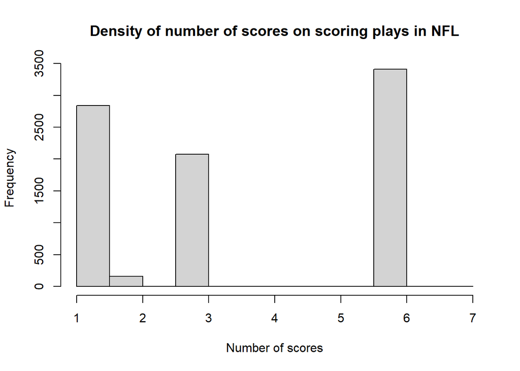

The expected scores in a try is close to 7 points for both Rugby league and NFL, with a lot of similarities.

## Modelling of NFL Score Distrbution

To model the NFL, we will need to look at the statistics in the goal distribution.

```
##           mean        std   play team
##  1:  2.6707416  1.4699213    try home
##  2:  2.2192339  1.4234193 conv_1 home
##  3:  0.1026895  0.3415982 conv_2 home
##  4:  1.6291769  1.2009633   kick home
##  5:  2.3219234  1.4204979   conv home
##  6: 23.3365933 10.0818019  score home
##  7:  2.4629177  1.3912635    try away
##  8:  1.9796251  1.3464020 conv_1 away
##  9:  0.1051345  0.3224064 conv_2 away
## 10:  1.5835371  1.2083814   kick away
## 11:  2.0847596  1.3332200   conv away
## 12: 21.7180114  9.6275854  score away
```

$N_{try} \sim Binom(N, p=\lambda_{try})\\ N_{conv} \sim Binom(N_{try},p=p_{conv})\\ N_{kick} \sim Binom(N, p=\lambda_{kick})\\ \lambda_{try} \sim N(\mu_{try}, \sigma^2_{try})\\ p_{conv} \sim N(\mu_{conv}, \sigma^2_{conv})\\ \lambda_{kick} \sim N(\mu_{kick}, \sigma^2_{kick})\\$

The N is chosen by estimating the variance of different parameters. And N = 9 for home and N = 8 for away is chosen.

$\bar{N}_{try} * (1-\bar{N}_{try})/N) < \sigma^{2}(N_{try})$

Using data from season 2015 to 2019, we fit the parameters as follows.

```
##       mean     std   parameter team
## 1: 1.62655 0.03287 lambda_kick home
## 2: 2.66136 0.03866  lambda_try home
## 3: 0.86945 0.00591      p_conv home
## 4: 1.58088 0.03185 lambda_kick away
## 5: 2.45441 0.03721  lambda_try away
## 6: 0.84640 0.00651      p_conv away
```

The variance of parameters is the variance arise from the fact that we fit the model from sampled data set but not from the population. So it does not capture the true variation from different teams playing each other.

The variance of the total scores arising from the distribution alone is the following.

$\sigma^{2}(Score) = \lambda_{trial} * (1- \lambda_{trial}/N) * (13*p_{conv}+36) + 9 * \lambda_{kick}*(1-\lambda_{kick}/N)$

The estimated variance versus actual variance is the following:

```
##    estimated   actual team
## 1:  100.6567 101.6427 home
## 2:   91.3873  92.6904 away
```

Obviously we want to reduce the estimation even further to account for the variance of the parameters. But it should be close enough to work with.

## Modelling Parameter Variance

The variance of the parameters can be estimated.

```
##       total from_dist   type team
## 1: 2.160669  1.878202  N_try home
## 2: 1.442313  1.334264 N_kick home
## 3: 1.935614  1.704672  N_try away
## 4: 1.460186  1.270088 N_kick away
```

```
##      estimate        type team
## 1: 0.12155507 lambda_kick home
## 2: 0.31777537  lambda_try home
## 3: 0.01824837      p_conv home
## 4: 0.21725389 lambda_kick away
## 5: 0.26393343  lambda_try away
## 6: 0.01957387      p_conv away
```

The variation of the parameters should infer the corresponding variation in expected goals. We can estimate the variance of the expected goals by using the closing total score line and closing home line.

```
##        mean      std team
## 1: 23.73446 3.585810 home
## 2: 21.58127 3.530063 away
```

The estimated expected score variance computed from the parameters are as follows.

```
##    parameter_estimate closing_line_estimate team
## 1:           16.21886              12.85803 home
## 2:           14.44460              12.46134 away
```

## Final Model

Given that the total score of the request is 25, which is only about half of that in NFL matches, I will try to generate a model based on half of the expectancy in $\lambda_{kick}$ and $\lambda_{try}$ but $p_{conv}$ remains the same. I also set the points from a try is 5 and points from extra point is 2 points. The kick worth 2 points as well.

If the traders give us a input of the expected goal, we would like to find the most possible parameters based on the input.

While we can assume the parameters follow independent Gaussian Distribution, and given a input of the expected goal, we can try to sample from the parameter space:

$P(\lambda_{kick},\lambda_{try},p_{conv}|score) = \frac{P((score-(5+2p_{conv})\lambda_{try})/2,\lambda_{try},p_{conv})}{\int\int P((score-(5+2p_{conv})\lambda_{try})/2,\lambda_{try},p_{conv})d\lambda_{try}dp_{conv}}$

It is easier to find parameters that is closest to the means and in the direction of the standard derivations, i.e. finding a scalar c such that:

$Score(\bar{\lambda}_{kick}+c\sigma(\lambda_{kick}),\bar{\lambda}_{try}+c\sigma(\lambda_{try}),\bar{p}_{conv}+c\sigma(p_{conv}))=score$

After the parameters are found, we will generate the score grid for each team. Assuming independence in the score grids for home and away team, we will be able to generate the match prices.

## Discussion

We still uses N=9 and 8 for home and away team. It is likely that the variance in the score distribution will drop further and we should choose a smaller Ns. The score density given in the request is also abnormally high, it is from physical standpoint that a team can get very few trials in 10 minutes only.

How teams react to score deficit is something to be investigated. It will generate the correlation between team scores and will affect the winning prices if the supremacy is large.